# matplotlib.axes.Axes.add_artist

**Axes.add_artist(*a*)[[source]](https://github.com/matplotlib/matplotlib/blob/v3.10.8/lib/matplotlib/axes/_base.py#L2308-L2328)**

Add an `Artist` to the Axes; return the artist.

Use `add_artist` only for artists for which there is no dedicated "add" method; and if necessary, use a method such as `update_datalim` to manually update the `dataLim` if the artist is to be included in autoscaling.

If no `transform` has been specified when creating the artist (e.g. `artist.get_transform() == None`) then the transform is set to `ax.transData`.

## Examples using `matplotlib.axes.Axes.add_artist`

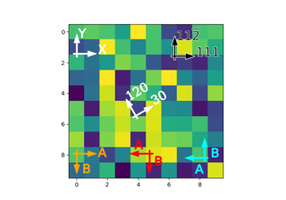

[Anchored Direction Arrow](https://matplotlib.org/stable/gallery/axes_grid1/demo_anchored_direction_arrows.html)

Anchored Direction Arrow

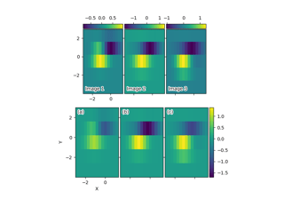

[Axes Grid2](https://matplotlib.org/stable/gallery/axes_grid1/demo_axes_grid2.html)

Axes Grid2

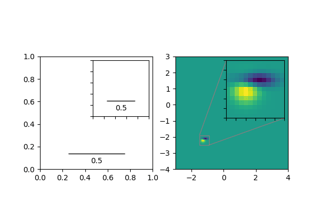

[Inset locator demo 2](https://matplotlib.org/stable/gallery/axes_grid1/inset_locator_demo2.html)

Inset locator demo 2

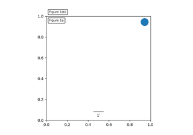

[Simple Anchored Artists](https://matplotlib.org/stable/gallery/axes_grid1/simple_anchored_artists.html)

Simple Anchored Artists

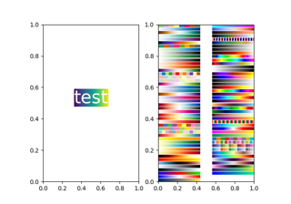

[BboxImage Demo](https://matplotlib.org/stable/gallery/images_contours_and_fields/demo_bboximage.html)

BboxImage Demo

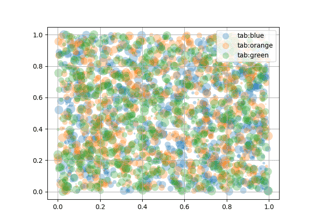

[Scatter plot with a legend](https://matplotlib.org/stable/gallery/lines_bars_and_markers/scatter_with_legend.html)

Scatter plot with a legend

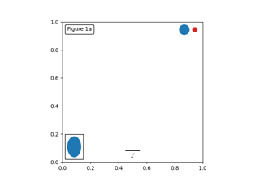

[Anchored Artists](https://matplotlib.org/stable/gallery/misc/anchored_artists.html)

Anchored Artists

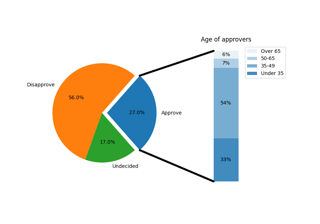

[Bar of pie](https://matplotlib.org/stable/gallery/pie_and_polar_charts/bar_of_pie.html)

Bar of pie

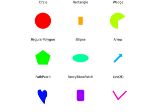

[Reference for Matplotlib artists](https://matplotlib.org/stable/gallery/shapes_and_collections/artist_reference.html)

Reference for Matplotlib artists

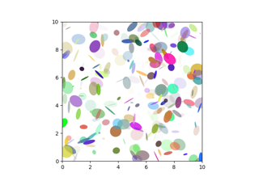

[Ellipse Demo](https://matplotlib.org/stable/gallery/shapes_and_collections/ellipse_demo.html)

Ellipse Demo

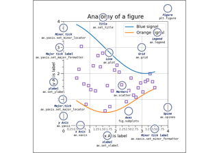

[Anatomy of a figure](https://matplotlib.org/stable/gallery/showcase/anatomy.html)

Anatomy of a figure

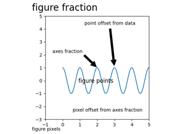

[Annotate plots](https://matplotlib.org/stable/gallery/text_labels_and_annotations/annotation_demo.html)

Annotate plots

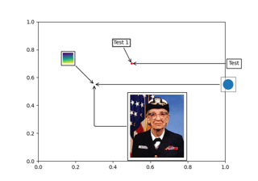

[AnnotationBbox demo](https://matplotlib.org/stable/gallery/text_labels_and_annotations/demo_annotation_box.html)

AnnotationBbox demo

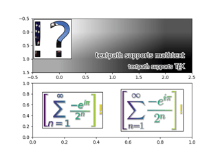

[Using a text as a Path](https://matplotlib.org/stable/gallery/text_labels_and_annotations/demo_text_path.html)

Using a text as a Path

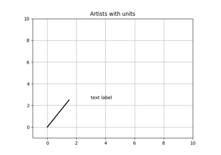

[Artist tests](https://matplotlib.org/stable/gallery/units/artist_tests.html)

Artist tests

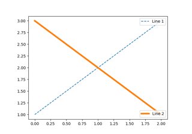

[Simple Legend02](https://matplotlib.org/stable/gallery/userdemo/simple_legend02.html)

Simple Legend02

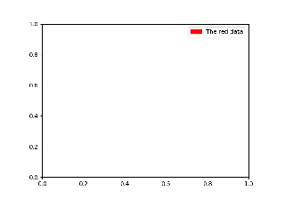

[Legend guide](https://matplotlib.org/stable/users/explain/axes/legend_guide.html)

Legend guide

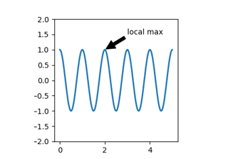

[Annotations](https://matplotlib.org/stable/users/explain/text/annotations.html)

Annotations